# NYPD Shooting Incident Shooting Data

Wei Yu (David) Wang

2023-08-22

This project aims to analyze a spreadsheet containing recorded shooting incidents that occurred in New York City through the end of the previous calendar year. The goal is to forecast crime rates in the five boroughs of NYC using Facebook Prophet to potentially improve police resources.

[The City of New York on data.gov](https://catalog.data.gov/dataset/nypd-shooting-incident-data-historic) describes this dataset as “a breakdown of every shooting incident that occurred in NYC going back to 2006 through the end of the previous calendar year. This data is manually extracted every quarter and reviewed by the Office of Management Analysis and Planning before being posted on the NYPD website. Each record represents a shooting incident in NYC and includes information about the event, the location and time of occurrence. In addition, information related to suspect and victim demographics is also included. This data can be used by the public to explore the nature of shooting/criminal activity.”

**This RMD can only be knitted to HTML because of the presence of an interactive chart**

## Importing Libraries

```r
library(tidyverse)
library(prophet)
library(dygraphs)
library(lubridate)
library(dplyr)
```

## Reading the Data

- ’read_csv() reads comma delimited csv files. A snapshot of the data is stored at this [address.](https://raw.githubusercontent.com/davidwangweiyu/data_science_asafield_coursework/main/NYPD_Shooting_Incident_Data__Historic_.csv)

```r
url <- "https://data.cityofnewyork.us/api/views/833y-fsy8/rows.csv?accessType=DOWNLOAD"
df <- read_csv(url)
```

## Tidying and Transforming Data

### Data Transformation

```r
df$ds <- mdy(paste(df$OCCUR_DATE))
head(df$ds)
```

```
## [1] "2021-05-27" "2014-06-27" "2015-11-21" "2015-10-09" "2009-02-19"
## [6] "2020-10-21"
```

- ’any(is.na(df#column)) checks if there are any empty values a specified column in a dataframe

```r
any(is.na(df$ds))
```

```
## [1] FALSE
```

```r
any(is.na(df$INCIDENT_KEY))
```

```
## [1] FALSE
```

In this case, there are no empty values to worry about.

### Data Cleaning

For this analysis, only 2 columns are kept, INCIDENT_KEY, and the date column created above.

```r
dfc <- df[, c("ds", "INCIDENT_KEY")]
head(dfc)
```

```
## # A tibble: 6 × 2
##   ds         INCIDENT_KEY
##   <date>            <dbl>
## 1 2021-05-27    228798151
## 2 2014-06-27    137471050
## 3 2015-11-21    147998800
## 4 2015-10-09    146837977
## 5 2009-02-19     58921844
## 6 2020-10-21    219559682
```

I wanted to identify if there were duplicate incident keys. It turns out, out of 27312 objects, only 21420 have unique incident keys. This could mean multiple perpetrators or victims per incident. Only unique incidents are kept.

- ’distinct()is used to select distinct or unique rows from the R data frame

```r
# Total objects
dim(dfc)[1]
```

```
## [1] 27312
```

```r
# Unique Objects
unique_dfc <- distinct(dfc, INCIDENT_KEY, .keep_all = TRUE)
dim(unique_dfc)[1]
```

```
## [1] 21420
```

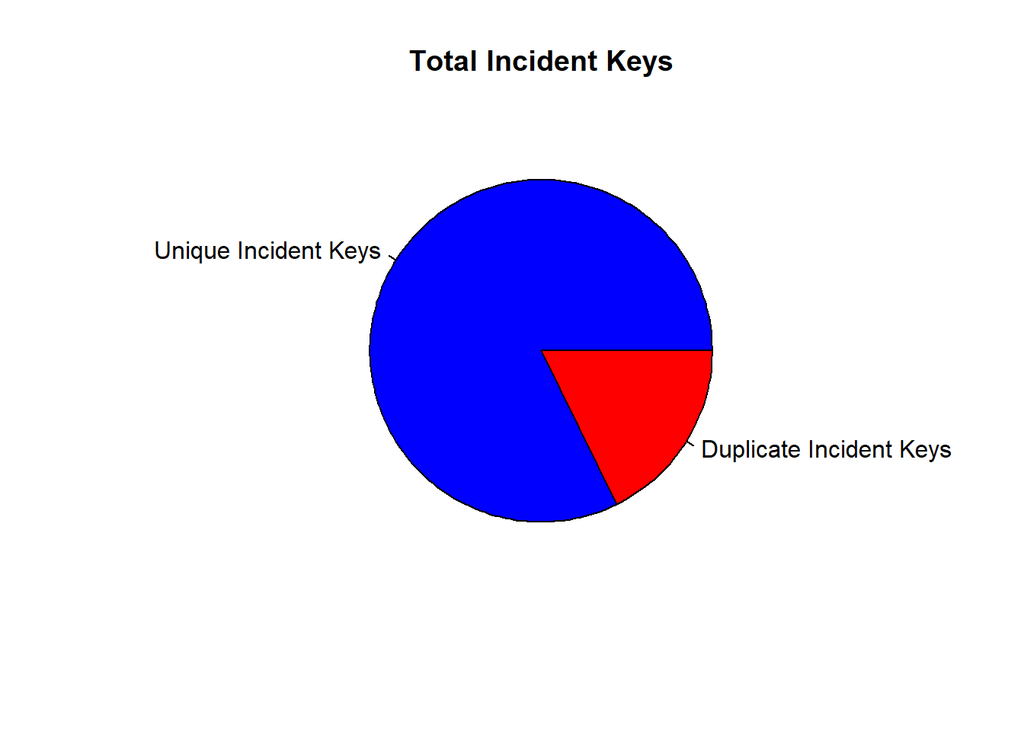

```r
# Creating a pie chart
pie_data <- c(dim(dfc)[1], dim(dfc)[1] - dim(unique_dfc)[1])
labels <- c("Unique Incident Keys", "Duplicate Incident Keys")
pie(pie_data, labels = labels, main = "Total Incident Keys", col = c("blue", "red"))
```

Lastly the data is grouped days.

- ’group_by() creates a grouped dataframe from an existing dataframe by an operation
- ’summarise() creates a new dataframe returning the combination of grouping variables

```r
# ds represents date, y represents the count of unique incidents within the timeframe

df_analysis <- unique_dfc %>%
  group_by(ds) %>%
  summarise(y = n())

head(df_analysis)
```

```
## # A tibble: 6 × 2
##   ds             y
##   <date>     <int>
## 1 2006-01-01     7
## 2 2006-01-02     3
## 3 2006-01-03     4
## 4 2006-01-04     4
## 5 2006-01-05     4
## 6 2006-01-06     3
```

```r
tail(df_analysis)
```

```
## # A tibble: 6 × 2
##   ds             y
##   <date>     <int>
## 1 2022-12-26     4
## 2 2022-12-27     1
## 3 2022-12-28     2
## 4 2022-12-29     2
## 5 2022-12-30     4
## 6 2022-12-31     1
```

## Analysis and Visualizations

- ’prophet() is used to fit the model with the dataframe being the historical dataframe
- ’make_future_dataframe takes the model object and a number of periods to forecast and produces a suitable dataframe
- ’predict(model, future) uses a prediction function to create a timeseries forecast
- ’prophet_plot_components(model, forecast) plots the timeseries forecast components

```r
m <- prophet(df_analysis)
```

```
## Disabling daily seasonality. Run prophet with daily.seasonality=TRUE to override this.
```

```r
future <- make_future_dataframe(m, periods = 365)
forecast <- predict(m, future)
tail(forecast[c('ds', 'yhat', 'yhat_lower', 'yhat_upper')])
```

```
##              ds     yhat yhat_lower yhat_upper
## 6121 2023-12-26 4.153298   1.494445   6.604461
## 6122 2023-12-27 4.010011   1.106870   6.763491
## 6123 2023-12-28 4.041931   1.206007   6.514613
## 6124 2023-12-29 4.513055   1.811936   7.297856
## 6125 2023-12-30 5.665389   2.968313   8.404747
## 6126 2023-12-31 5.912610   3.465697   8.738252
```

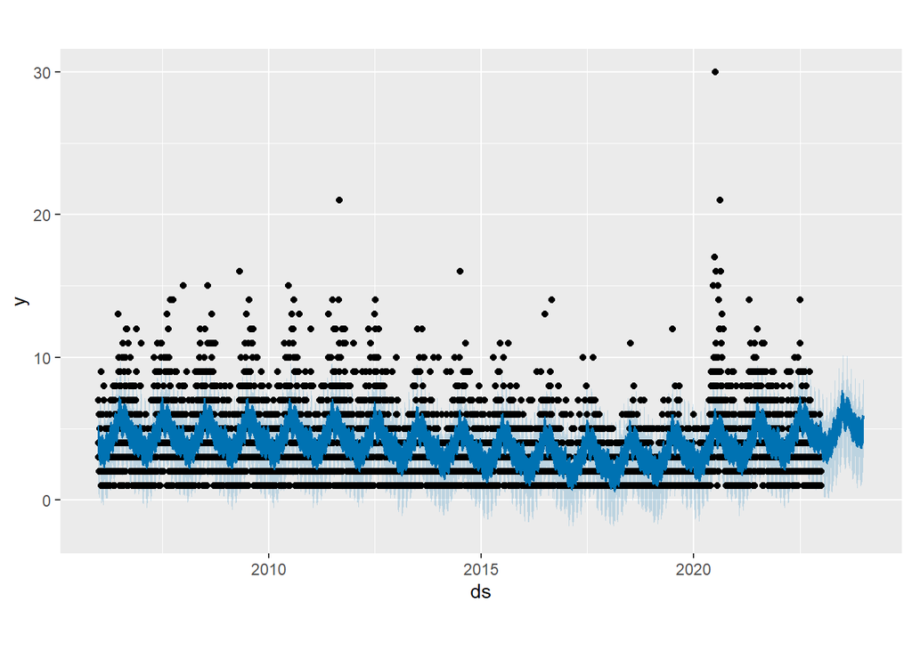

```r
# Plotting forecast analysis results
plot(m, forecast)
```

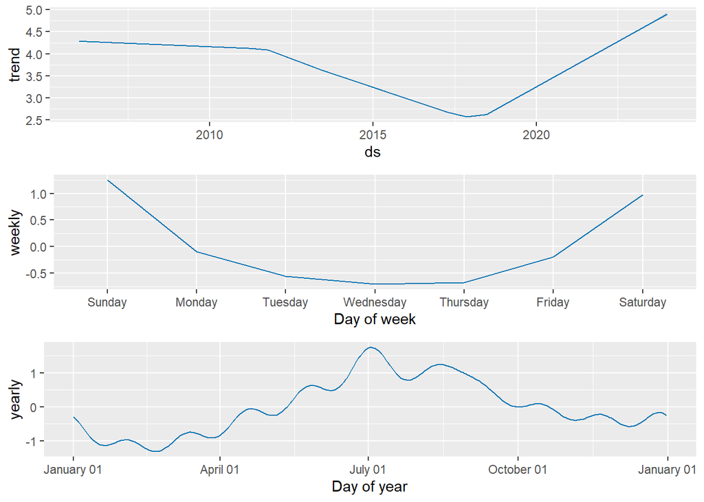

```r
# Components
prophet_plot_components(m, forecast)
```

```r
# Interactive plot
dyplot.prophet(m, forecast)
```

[interactive chart not shown]

## Conclusion and Possible Sources of Biases

### Bias Sources

Working with police data, there is inherent bias in that the data is solely sourced from the NYPD. If a shooting incident occurs and is not recorded by the NYPD, it is not reflected in our data analysis. My analysis also only looks at individual incidents and treats multi-perpetrator and multi-victim events as a single incident, even though these events can be more severe. In terms of algorithmic bias, only visual inspections of the model was done with no validation statistics produced. This results in no metrics produced on how well the model performed. There is also an option to add additional seasonality such as holidays, major events that was not implemented which could provide a more complete forecast and analysis. Lastly, this analysis only explores unique incidents and has omitted fields such as race, age, and gender potentially adding bias in not seeing potential systemic patterns relating to these attributes.

## Citation

Taylor, S. J., & Letham, B. (2017). Forecasting at Scale. https://doi.org/10.7287/peerj.preprints.3190v2

Forecasting at scale. Prophet. (n.d.). https://facebook.github.io/prophet/